# Презентация по лабораторной работе №7

Математическое моделирование

Арбатова Варвара Петровна

1132236020@rudn.ru

Российский университет дружбы народов

2026-05-12

# Информация

## Докладчик

- Арбатова Варвара Петровна
- студентка
- Российский университет дружбы народов им. П. Лумумбы
- [1132236020@rudn.ru]
- https://vparbatova.github.io/ru/

# Цель работы

Исследовать простейшую математическую модель эффективности рекламы.

# Задание

## Вариант 21

Построить график распространения рекламы, математическая модель которой описывается следующим уравнением:

При этом объем аудитории $N = 800$, в начальный момент о товаре знает 11 человек. Для случая 2 определить в какой момент времени скорость распространения рекламы будет иметь максимальное значение.

# Теоретическое введение

Пусть некая фирма начинает рекламировать новый товар. Модель рекламной кампании описывает скорость изменения числа информированных покупателей и основывается на предположении, что скорость пропорциональна числу ещё не знающих о товаре покупателей. Также учитывается вклад уже информированных покупателей как дополнительных рекламных агентов.

В итоге получаем уравнение

$$\dfrac{dn}{dt} = (\alpha_1+\alpha_2 n(t))(N-n(t))$$

# Выполнение лабораторной работы

## Реализация в Julia

```julia
using DifferentialEquations, Plots
f(n, p, t) = (p[1] + p[2]*n)*(p[3] - n)
f3(n, p, t) = (p[1]*t + p[2]*t*n)*(p[3]-n)

N = 800
p1 = [0.21, 0.00008, N]
p2 = [0.000012, 0.8, N]
p3 = [0.1, 0.1, N]
n_0 = 11
tspan1 = (0.0, 20.0)
tspan2 = (0.0, 0.04)
tspan3 = (0.0, 1.0)
prob1 = ODEProblem(f, n_0, tspan1, p1)
prob2 = ODEProblem(f, n_0, tspan2, p2)
prob3 = ODEProblem(f3, n_0, tspan3, p3)
```

## Реализация в Julia

```julia
sol1 = solve(prob1, Tsit5(), saveat = 0.01)
plot(sol1, yaxis = "N(t)", label="n")
```

## Реализация в Julia

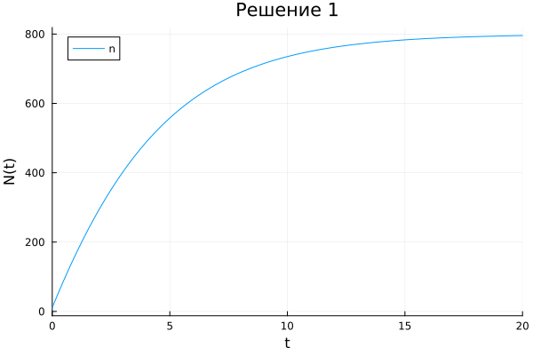

Рисунок 1: График изменения интенсивности рекламы для первого случая

В первом случае $\alpha_1(t)$ на порядки выше, чем $\alpha_2(t)$, поэтому мы получили модель Мальтуса.

## Реализация в Julia

Найдем решение для второго случая и найдем время максимальной скорости:

```julia
sol2 = solve(prob2, Tsit5(), saveat = 0.0001)
dev = [sol2(i, Val{1}) for i in 0:0.0001:0.04]
findall(x -> x == maximum(dev), dev)
sol2.t[165]
```

## Реализация в Julia

```julia
x = sol2.t[165]
y = sol2.u[165]
plot(sol2, yaxis="N(t)", label="n")
scatter!((x,y), leg=:bottomright, label="максимальная скорость")
```

## Реализация в Julia

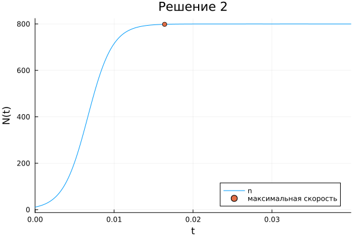

Рисунок 2: График изменения интенсивности рекламы для второго случая

Во втором случае получили логистическую кривую.

## Реализация в Julia

Найдем решение для третьего случая:

```julia
sol3 = solve(prob3, Tsit5(), saveat = 0.0001)
dev = [sol3(i, Val{1}) for i in 0:0.0001:1]
findall(x -> x == maximum(dev), dev)
sol3.t[1066]
```

## Реализация в Julia

```julia
plot(sol3, markersize=:15, yaxis="N(t)", label="n")
scatter!((sol3.t[1066], sol3.u[1066]), label="максимальная скорость")
```

## Реализация в Julia

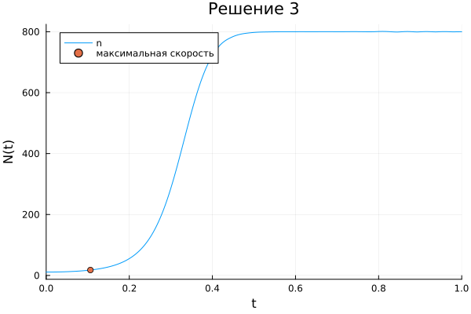

Рисунок 3: График изменения интенсивности рекламы для третьего случая

## Реализация в Julia

Сравним коэффициенты модели.

```julia
plot([sin(i)*0.25 for i in 0:0.0001:0.2], label="a_1")
plot!([0.75*i for i in 0:0.0001:0.2], label="a_2")
```

[output not shown]

## Реализация в Julia

[figure not shown]

График действительно является логистической кривой.

# Выводы

Исследовали математическую модель эффективности рекламы.